# Forecast Averaging for Inflation

Kieran Stewart-Phillips

April 10, 2022

```r
require(fpp3)
require(tsibble)
require(tidyverse)
require(tidyquant)
require(lubridate)
require(timetk)
require(kableExtra)
require(ggplot2)
require(reshape2)
```

```r
varList <- c("PCEPI", "UNRATE", "TCU", "IPMAN", "HOUST")
X <-
  tq_get(varList, get = "economic.data", from = "1982-01-01") %>%
  mutate(Month = yearmonth(date), value = price) %>%
  dplyr::select(-c(date, price)) %>%
  as_tsibble(index = Month, key = symbol)
Xw <- X %>%
  pivot_wider(names_from = symbol, values_from = value) %>%
  as_tsibble()  %>%
  drop_na()
```

### *Introduction*

Inflation universally remains a massively impactful factor within the economic health of a country. While not necessarily the main cause of economic recession, rising prices of consumer goods within an economy does tie into overall economic success as seen through events such as the 2008 recession where inflation rose above nominal wages, subsequently leading to a decrease in overall real wages. General theory also tells us that overall inflationary growth is usually followed by a recession due to unsustainable booms depending on how large the economic growth is. Thus, a growing area of concern for economic study in the modern day largely revolves around using analysis of inflation to better predict subsequent economic development. In an attempt to go about this, many economists have used economic modelling in order to try and understand various metrics that could come to influence inflation. One such model, the Phillips Curve, is employed within this paper and tested against with the hope that a model that better predicts inflation can be found. To see specific code used in this paper, please see the R markdown file at the attached link here:

[Forecast Averaging code](https://kieranstewart-phillips.github.io/projects.html)

### *The Phillips Curve*

The original Stock & Watson specification for the Phillips Curve is as follows:

$$\pi^{12}_t - \pi_{t-12} = \phi +
\beta(B)\Delta_{\pi_{t-12}} + \gamma(B)_{u_{t-12}} + \varepsilon_t$$

The curve identifies that inflation and unemployment have a stable and inverse relationship. In this paper, we will measure inflation using the Personal Consumption Expenditures Price Index ( *PCEPI* ), while the unemployment rate ( *UNRATE* ) will be represented in the model by $u_t$.

### *Forecast Outline*

Specifically, this paper seeks to test other outside variables in place of unemployment to forecast inflation. Each outside variable’s forecast will be graphed alongside the unemployment rate and an average of all outside variables will be calculated to analyze an overall impact from the variables.

Outside variables will be represented as:

*TCU* - Capacity Utilization: Total Index

*IPMAN* - Industrial Production: Manufacturing (NAICS)

*HOUST* - New Privately-Owned Housing Units Started: Total Units

Variables were picked with the purpose of correlation to inflation being in mind. Capacity utilization rates, for instance, generally fall steeply in recessions and rise during recovery with higher capacity utilization usually is related to increased inflation. Similarly, the level of Industrial Production likely has an impact on inflation as seen recently with the supply chain crisis and subsequent inflation throughout late 2021 and 2022. For replicability purposes, all data being tested starts from 1982 and was acquired from the Federal Reserve Economic Data (FRED). All variables were seasonally adjusted.

```r
mutatedvar <- Xw %>% select(c("PCEPI", "UNRATE", "TCU", "IPMAN", "HOUST")) %>%
  mutate(inflation = 1200*log(PCEPI/lag(PCEPI))) %>%
  mutate(dinflation = inflation - lag(inflation, 1)) %>%
  mutate(dinflation12 = 100*log(PCEPI/lag(PCEPI, 12)) - lag(inflation, 12)) %>%
  mutate(unrate = UNRATE - lag(UNRATE)) %>%
  mutate(tcu = TCU - lag(TCU)) %>%
  mutate(ipman = 1200*log(IPMAN/lag(IPMAN))) %>%
  mutate(houst = 100*log(HOUST/lag(HOUST))) %>%
  select(-c(PCEPI, UNRATE, TCU, IPMAN, HOUST)) %>%
  drop_na()
train_data <- mutatedvar %>% filter_index(~ "2018-12")
test_data <- mutatedvar %>% filter_index("2019-01" ~ .)
```

### *Forecasting Results*

The first table below the forecast graph indicates the Mean Absolute Percentage Error values per each variable tested in the sample denoted by *training* . MAPE can be summarized as the individual absolute errors of the model divided by the demand. The MAPE values here can be useful for analyzing accuracy as a lower MAPE indicates a better model.

The *Training* table shows that the best performing models, or the models with the lowest mean absolute percentage errors, were using the Industrial Production variable, followed by the Capacity Utilization variable, and then this test’s overall averaged lagged model denoted by *ensemble* . While the Capacity Utilization and Industrial Production variables were close in value (181.8317 and 180.6336 respectively), the overall averaged model was rather higher while still being the third best model.

The last table shows the relative MAPE values out of sample for the testing variables denoted by *Test* . The forecasting here indicates that the best performing models were Capacity Utilization variable followed by the *ensemble* model. Interestingly enough, both values were quite close being only 3.3542 away from eachother, while the next highest MAPE, the Industrial Production variable, was 7.9159 points higher than our *ensemble* test.

Between both tables, the unemployment rate and the housing variables ended up having higher MAPE values than the other models, switching between the bottom two models in terms of performance. This tends to fall in line with initial speculations with regards to unemployment rate due to its inverse relationship with inflation as well as the housing variable as one might expect to find that an increase in the number of New Privately-Owned Housing Units would likely indicate an increase consumer power and lower inflation.

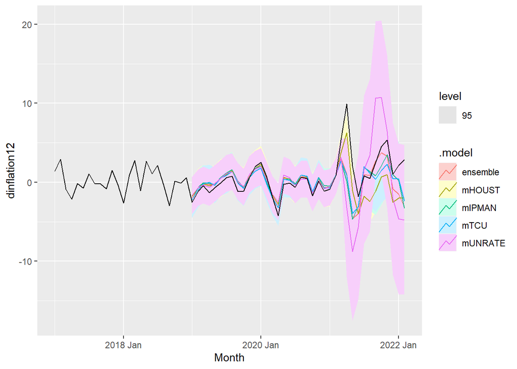

```r
fitensemble <- fitPC %>%
  mutate(ensemble = (mUNRATE + mTCU + mIPMAN + mHOUST)/4)
fcensemble <- fitensemble %>% forecast(new_data = test_data)
fcensemble %>% autoplot(filter(mutatedvar, year(Month) > 2016), level = c(95))
```

```r
fcensemble01 <- accuracy(fitensemble) %>%
  select(c(".model", ".type", "MAPE")) %>%
  kable(format = "html", table.attr = "style='width:30%;' ") %>%
  kableExtra::kable_styling()
fcensemble01
```

| .model | .type | MAPE |
| --- | --- | --- |
| mUNRATE | Training | 195.0650 |
| mTCU | Training | 181.8317 |
| mIPMAN | Training | 180.6336 |
| mHOUST | Training | 204.6392 |
| ensemble | Training | 188.5813 |

```r
fcensemble02 <- accuracy(fcensemble, mutatedvar) %>%
  select(c(".model", ".type", "MAPE")) %>%
  kable(format = "html", table.attr = "style='width:30%;' ") %>%
  kableExtra::kable_styling()
fcensemble02
```

| .model | .type | MAPE |
| --- | --- | --- |
| ensemble | Test | 106.5014 |
| mHOUST | Test | 131.2759 |
| mIPMAN | Test | 114.4173 |
| mTCU | Test | 103.1472 |
| mUNRATE | Test | 154.6405 |